# Heat, flood and tornados kill and maim the most people in the US, while flood and hurricanes cause the most damage

Phillip Rowe

8/23/2019

## Synopsis

1. To help local and national US government officials respond to health and economic risks from weather events, we analyzed the data from the U.S. National Oceanic and Atmospheric Administration’s (NOAA) storm database of events from 1951-2011, focusing on three dimensions: time, geographic location, and weather event type.
2. For time, the majority of data was collected between 1992 and 2011; thus, we broke our analysis into 5 periods of 4 years each, to smooth for weather events which had large impact but did not occur annually.
3. We believe a 4-year period is also probably more suitable to the budgeting and planning schedules of government officials than a longer period (such as a decade).
4. Geographic analysis was limited to four time zones: PST, MST, CST, EST.
5. Weather events were cleaned up (i.e., recategorized) and then filtered to include only twelve types of events, each of which accounted for more than 2% of at least one of the impacts (fatalities, injuries, property damage, or crop damage).
6. From this analysis, we found that 5 types of weather (heat, flood, wind, tornadoes, and lightning) accounted for more than 75% of fatalities and injuries in the 20 years analyzed, while flood and hurricanes were the main contributors to property damage.
7. Flood and drought were the main causes of crop damage.
8. In addition, a vast majority of fatalities and crop damage and injuries were concentrated in the Eastern Standard and Central Standard time zones, while the most property damage was suffered in the Central Standard and Pacific Standard time zones.
9. The Mountain Standard time zone, which was the least impacted across all risks, likely due to lower population density, had a large portion of property damage due to hail, unlike other regions.

## Data Processing

#### Contents

1. **Load the data and pre-process data:**
2. **Analyze and limit data by cutoff year and timezone:**
3. **Clean/recategorize weather event types:**
4. **Melt and recast data:**
5. **Time period analysis:**
6. **Geographic (time zone) analysis:**
1. **Load the data and pre-process data:** filter the variables to be those relevant for our analysis, including formatting the bgn_date variable as a date, cleaning damage coding, and adding new variables for **year** and damage in millions of dollars (**propertydamage_M** and **cropdamage_M**).

```r
library("dplyr")
library(lubridate)
library(ggplot2)
library(downloader)
library('stringr')
library('tibble')
library('reshape2')

#---------------------------------------------------------------------------------------
#
# DATA PROCESSING
# 1. **Load the data and pre-process data:**
#
#---------------------------------------------------------------------------------------

# uncomment following two lines for initial download
url<-'https://d396qusza40orc.cloudfront.net/repdata%2Fdata%2FStormData.csv.bz2'
download(url,dest="storm_data.csv.bz2")

sdata<-read.csv('storm_data.csv.bz2')

# Fields relevant for health: FATALITIES,INJURIES,
# Fields relevant for economic impact: PROPDMG,PROPDMGEXP,CROPDMG,CROPDMGEXP
# Fields relating to geography: STATE__,TIME_ZONE,STATE
# Other fields: EVTYPE,BGN_DATE
cols<-c('EVTYPE','BGN_DATE','FATALITIES','INJURIES','PROPDMG','PROPDMGEXP',
        'CROPDMG','CROPDMGEXP','TIME_ZONE','STATE__','STATE')

mydf<-select(sdata,cols)
names(mydf)<-tolower(names(mydf))
mydf$evtype<-tolower(mydf$evtype)
mydf$bgn_date<-gsub("\\s0:00:00?","",mydf$bgn_date)
mydf$bgn_date<-as.Date(mydf$bgn_date,"%m/%d/%Y")

# remove rows where the coding for property damage is unclear; there are only 14 of these rows
# and they do not include any fatalities or injuries, so the impact on our analysis
# is likely low
prep_propdmgexp<-function(mydf) {
     mydf<-filter(mydf,!(propdmgexp%in%c("?","-","+")))
     mydf<-filter(mydf,!(cropdmgexp%in%c("?")))
     # change coding to be power of ten
     mydf$propdmgexp<-tolower(mydf$propdmgexp)
     mydf$propdmgexp[grep("k",mydf$propdmgexp)]<-3
     mydf$propdmgexp[grep("h",mydf$propdmgexp)]<-2
     mydf$propdmgexp[grep("b",mydf$propdmgexp)]<-9
     mydf$propdmgexp[grep("m",mydf$propdmgexp)]<-6
     mydf$propdmgexp<-as.numeric(mydf$propdmgexp)
     mydf$propdmgexp[is.na(mydf$propdmgexp)]<-0
     return(mydf)
}

prep_cropdmgexp<-function(mydf) {
     mydf$cropdmgexp<-tolower(mydf$cropdmgexp)
     mydf$cropdmgexp[grep("k",mydf$cropdmgexp)]<-3
     mydf$cropdmgexp[grep("b",mydf$cropdmgexp)]<-9
     mydf$cropdmgexp[grep("m",mydf$cropdmgexp)]<-6
     mydf$cropdmgexp<-as.numeric(mydf$cropdmgexp)
     mydf$cropdmgexp[is.na(mydf$cropdmgexp)]<-0
     return(mydf)
}

mydf<-prep_cropdmgexp(mydf) %>% prep_propdmgexp
```

```
FALSE Warning in prep_cropdmgexp(mydf): NAs introduced by coercion
```

```r
# Add three new column variables: year, propdamage_M, cropdamage_M
# using cleaned up codes for damage
mydf$year<-(year(mydf$bgn_date))
mydf$propdamage_M<-with(mydf,propdmg*10^(propdmgexp-6))
mydf$cropdamage_M<-with(mydf,cropdmg*10^(cropdmgexp-6))
```

```r
#---------------------------------------------------------------------------------------
#
# DATA PROCESSING
#
# 2. **Analyze and limit data by cutoff year and timezone:**
#
#---------------------------------------------------------------------------------------

premelt<-melt(data=mydf,id.vars=c("evtype","year","time_zone"),
              measure.vars=c("fatalities","injuries","propdamage_M","cropdamage_M"))

# these were used in barplot code shown in the Appendix, not used in report
var<-c('health','health','economic','economic')
names(var)<-c('fatalities','injuries','propdamage_M','cropdamage_M')
premelt$impact<-var[premelt$variable]
premelt$damage<-rep("damage",length(premelt[,1]))

precast_year<-dcast(premelt,year~variable,fun=sum)
# sort and show variables by year; last 20 years are worth focusing on
head(precast_year[order(-precast_year$propdamage_M),],30)
```

```
##    year fatalities injuries propdamage_M cropdamage_M
## 57 2006        599     3368       121615         3490
## 56 2005        469     1834        96485         3998
## 55 2004        370     2426        25030         1396
## 62 2011       1002     7792        20286          585
## 44 1993        298     2149        15910         5552
## 59 2008        488     2703        15064         2075
## 49 1998        687    11177        11208         4427
## 46 1995       1489     4480        10421         2914
## 54 2003        443     2931         9915         1097
## 52 2001        469     2721         9727         1773
## 48 1997        601     3800         9303         1171
## 61 2010        425     1855         8787         1734
## 50 1999        908     5148         8454         3488
## 47 1996        542     2717         5779         1841
```

[output cut: 16 more lines]

```r
precast_tz<-dcast(premelt,time_zone~variable,fun=sum)
# sort and show variables by time zone; obviously 4 stand out
head(precast_tz[order(-precast_tz$propdamage_M),],10)
```

```
##    time_zone fatalities injuries propdamage_M cropdamage_M
## 7        CST       9246   105685       204997        32214
## 18       PST        902     4421       125910         4085
## 10       EST       3894    25433        72762        10146
## 16       MST        738     3832        10128          604
## 3        AST        189      164         2427          615
## 14       HST         46       95          837            7
## 20       SST         90      558          501          104
## 21       UNK          0        0          250            0
## 8        EDT          9      171          228           10
## 2        AKS          7        2          119            0
```

```r
main_zones<-c('PST','EST','MST','CST')
data_recent_fourtz<-filter(mydf,year>=1992 & time_zone%in%main_zones)
```

3. **Clean/recategorize weather event types:** There were 985 unique event types in the original **sdata** dataframe, which was loaded raw without any filtering. After filtering the data down to the last 20 years and to four main time zones, there were still 820 unique event types. Through an iterative process of adding text recognition phrases and running them in the **prep_evtype()** function and looking at the largest contributing event types in the **total_by_type** aggregated dataframe, we reduced the unique event types to 313 before calculating which were the most significant event types. We chose the all events that accounted for more than 2% of the total, for each of the four categories of impact. We then did a union operation of all these factors to come up with 12 unique weather events, and then filtered the data to only include these rows.

```r
#---------------------------------------------------------------------------------------
#
# DATA PROCESSING
#
# 3. **Clean/recategorize weather event types:**
# we analyze a bit more to find the top event types per risk, which is the hardest
# task given the messy recordkeeping
#---------------------------------------------------------------------------------------

length(unique(sdata$EVTYPE))
```

```
## [1] 985
```

```r
length(unique(data_recent_fourtz$evtype))
```

```
## [1] 820
```

```r
# Run this first and search for poorly categorized/ redundant weather events
total_by_type_dirty<-aggregate(cbind(propdamage_M,cropdamage_M,injuries,fatalities) ~ evtype,
                         data_recent_fourtz, sum)
head(total_by_type_dirty[order(-total_by_type_dirty$propdamage_M),],20)
```

```
##                         evtype propdamage_M cropdamage_M injuries
## 144                      flood       143856         5481     6786
## 332          hurricane/typhoon        69035         2604      922
## 539                storm surge        43287            0       36
## 694                    tornado        26651          334    24588
## 130                flash flood        15306         1221     1763
## 200                       hail        15163         2474     1067
## 323                  hurricane         9906         2189       44
## 707             tropical storm         7575          569      338
## 810               winter storm         6601           25     1321
## 475                river flood         5102         5026        2
## 291                  high wind         5013          627     1110
## 799                   wildfire         4713          287      903
## 540           storm surge/tide         4635            0        5
## 346                  ice storm         3897         5021     1941
```

[output cut: 27 more lines]

```r
prep_evtype<-function(mydf) {
        # consolidate categories of weather
        mydf$evtype[grep("+tornado+",mydf$evtype)]<-"tornado"
        mydf$evtype[grep("+heavy rain+",mydf$evtype)]<-"heavy rain"
        mydf$evtype[grep("+heat+",mydf$evtype)]<-"heat"
        mydf$evtype[grep("+flood+",mydf$evtype)]<-"flood"
        mydf$evtype[grep("+rip current+",mydf$evtype)]<-"rip current"

        mydf$evtype[grep("+wind+",mydf$evtype)]<-"wind"
        mydf$evtype[grep("+cold+",mydf$evtype)]<-"cold/freeze"
        mydf$evtype[grep("+hurricane+",mydf$evtype)]<-"hurricane/tropical storm"
        mydf$evtype[grep("+typhoon+",mydf$evtype)]<-"hurricane/tropical storm"
        mydf$evtype[grep("+tropical storm+",mydf$evtype)]<-"hurricane/tropical storm"

        mydf$evtype[grep("+snow+",mydf$evtype)]<-"snow"
        mydf$evtype[grep("+blizzard+",mydf$evtype)]<-"snow"
        mydf$evtype[grep("+ice storm+",mydf$evtype)]<-"snow"
        mydf$evtype[grep("+winter storm+",mydf$evtype)]<-"snow"
        mydf$evtype[grep("+freeze+",mydf$evtype)]<-"cold/freeze"
        mydf$evtype[grep("+frost+",mydf$evtype)]<-"cold/freeze"

        mydf$evtype[grep("+fire+",mydf$evtype)]<-"fire"
        mydf$evtype[grep("+high surf+",mydf$evtype)]<-"storm surge/high surf"
        mydf$evtype[grep("+storm surge+",mydf$evtype)]<-"storm surge/high surf"
        mydf$evtype[grep("+hail+",mydf$evtype)]<-"hail"
        return(mydf)
}

df_type_clean<-prep_evtype(data_recent_fourtz)

total_by_type<-aggregate(cbind(propdamage_M,cropdamage_M,injuries,fatalities) ~ evtype,
                         df_type_clean, sum)
head(total_by_type[order(-total_by_type$propdamage_M),],30)
```

```
##                       evtype propdamage_M cropdamage_M injuries fatalities
## 59                     flood       165736        11933     8586       1452
## 97  hurricane/tropical storm        90007         5534     1354        170
## 184    storm surge/high surf        47999            0      189        112
## 259                  tornado        28306          336    24649       1688
## 79                      hail        15404         2494     1077         10
## 306                     wind        13340         1820     8260       1158
## 182                     snow        12041         5292     5183        537
## 57                      fire         8408          391     1586         90
## 85                heavy rain         3184          781      245         84
## 173      severe thunderstorm         1205            0        0          0
## 32                   drought         1040        13957        4          0
## 116                lightning          389            9     5206        806
## 110                landslide          308           20       49         36
## 23               cold/freeze          134         3396      282        230
```

[output cut: 16 more lines]

```r
length(unique(df_type_clean$evtype))
```

```
## [1] 313
```

```r
# now down to 313 unique event types
# let's see how many of these account for most of results

# - - - - - - - - - - - - - - -

total_by_type$pctprop<-with(total_by_type, round(propdamage_M/sum(propdamage_M),2))
total_by_type$pctcrop<-with(total_by_type, round(cropdamage_M/sum(cropdamage_M),2))
total_by_type$pctfat<-with(total_by_type, round(fatalities/sum(fatalities),2))
total_by_type$pctinj<-with(total_by_type, round(injuries/sum(injuries),2))

crop_events<-filter(total_by_type,total_by_type$pctcrop>0.02)$evtype
prop_events<-filter(total_by_type,total_by_type$pctprop>0.02)$evtype
fat_events<-filter(total_by_type,total_by_type$pctfat>0.02)$evtype
inj_events<-filter(total_by_type,total_by_type$pctinj>0.02)$evtype

econ_risks<-union(fat_events,inj_events)
health_risks<-union(crop_events,prop_events)
risks<-union(econ_risks,health_risks)
risks
```

```
##  [1] "flood"                    "heat"
##  [3] "lightning"                "rip current"
##  [5] "snow"                     "tornado"
##  [7] "wind"                     "cold/freeze"
##  [9] "drought"                  "hail"
## [11] "hurricane/tropical storm" "storm surge/high surf"
```

```r
# filtering data down to these 12 risks

final_data<-filter(df_type_clean,evtype%in%risks)
length(unique(final_data$evtype))
```

```
## [1] 12
```

4. **Melt and recast data:**

```r
#---------------------------------------------------------------------------------------
#
# DATA PROCESSING
# 4. **Melt and recasting data:**
#
#---------------------------------------------------------------------------------------

myperiod<-c(rep('1992-5',4),rep('1996-1999',4),rep('2000-3',4),rep('2004-7',4),rep('2008-11',4))
names(myperiod)<-c(1992:2011)

final_data$period<-myperiod[as.character(final_data$year)]


# first we want to melt the df into tidy date, with one observation per row
# and introduce the concept of health and economic cost
# health = of type fatalities or injuries and measured by body count
# economic = of type property or crop damage and measured by USD Millions
# so we will have a long skinny dataframe where we have a year, timezone, type of event,
# and only one type of the four costs above measured

melted<-melt(data=final_data,id.vars=c("evtype","period","time_zone"),
             measure.vars=c("fatalities","injuries","propdamage_M","cropdamage_M"))

var<-c('health','health','economic','economic')
names(var)<-c('fatalities','injuries','propdamage_M','cropdamage_M')

melted$impact<-var[melted$variable]
melted$damage<-rep("damage",length(melted[,1]))

casted<-dcast(melted,evtype+time_zone+period+variable+impact~damage,fun=sum)
```

5. **Time period analysis:** We used the **ggplot**/ **geom_bar()** plots with free y-axis scales to plot the damage in 4 four barplots (four impact variables) over the five time periods (see Figure 1). We customized the color palette of fill colors so that each weather event was matched to a unique color that, when possible, made intuitive sense (e.g., flood was blue, snow was white). We set customized the y-labels to be more aesthetically pleasing.

```r
#---------------------------------------------------------------------------------------
#
# DATA PROCESSING
# 4. Time period plot
#
# Now we set up 5 periods of 4 years each, covering the 20 years from 1992-2011
# the named list myperiod acts as a dictionary for plotting functions for mapping year to period
#---------------------------------------------------------------------------------------

prop_total = sum(subset(casted,variable=="propdamage_M")$damage)
crop_total = sum(subset(casted,variable=="cropdamage_M")$damage)
fat_total = sum(subset(casted,variable=="fatalities")$damage)
inj_total = sum(subset(casted,variable=="injuries")$damage)
print(paste("Property damage $M total 1992-2011 from 12 main events:", prop_total))
```

```
## [1] "Property damage $M total 1992-2011 from 12 main events: 374414"
```

```r
print(paste("Property damage $M total 1992-2011 from 12 main events:", crop_total))
```

```
## [1] "Property damage $M total 1992-2011 from 12 main events: 45674"
```

```r
print(paste('Property damage is ~',round(prop_total/crop_total,0),'x larger'))
```

```
## [1] "Property damage is ~ 8 x larger"
```

```r
print(paste("Total fatalities from 1992-2011 from 12 main events:", fat_total))
```

```
## [1] "Total fatalities from 1992-2011 from 12 main events: 9821"
```

```r
print(paste("Total injuries from 1992-2011 from 12 main events:", inj_total))
```

```
## [1] "Total injuries from 1992-2011 from 12 main events: 64484"
```

```r
print(paste('Injury total is ~',round(inj_total/fat_total,0),'x larger'))
```

```
## [1] "Injury total is ~ 7 x larger"
```

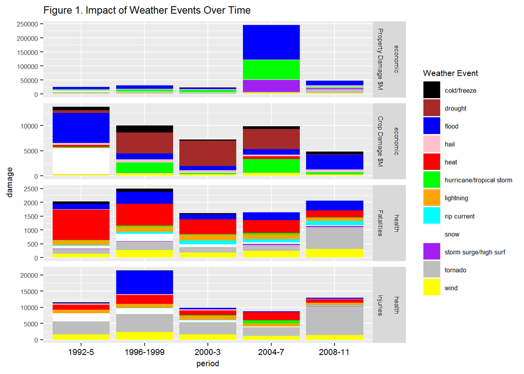

```r
mycolors= c('black','brown','blue', 'pink','red','green', 'orange','cyan',
            'white','purple','gray','yellow')

damage.labs<-c("Property Damage $M","Crop Damage $M","Fatalities","Injuries")
names(damage.labs)<-c("propdamage_M","cropdamage_M","fatalities","injuries")

theme_update(text = element_text(size=8))
 # for the main title

time_period_plot<-ggplot(casted,aes(period,y=damage,fill=evtype,order=variable)) +
        geom_bar(stat='identity') + facet_grid(impact+variable ~.,scales="free_y",
                                               labeller=labeller(variable=damage.labs))+
        theme(axis.text.x=element_text(size=8,colour='black',angle=0))+
        ggtitle('Figure 1. Impact of Weather Events Over Time')+
        labs(fill="Weather Event", scale_fill_manual(values = mycolors))
time_period_plot+ scale_fill_manual(values = mycolors)
```

6. **Geographic (time zone) analysis:** Because our analysis is directed to national and local government decisionmakers, it made sense to also include a geographic analysis of the data across the four impact variables. We used the stacked barplots with similar coloration scheme in Figure 2.

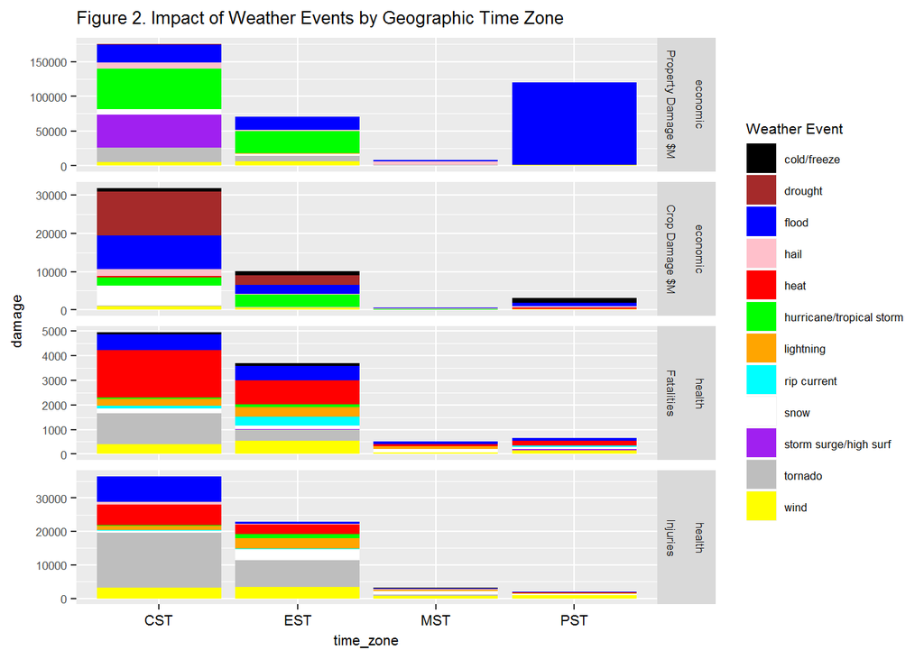

```r
#---------------------------------------------------------------------------------------
#
# DATA PROCESSING
# 5. Geographic plot (by time zone)
#
#---------------------------------------------------------------------------------------

# TIME ZONE BY IMPACT
time_zone_plot<-ggplot(casted,aes(time_zone,y=damage,fill=evtype,order=variable))+
        geom_bar(stat='identity')+
        facet_grid(impact+variable ~.,scales="free_y",
                   labeller=labeller(variable=damage.labs))+
        theme(axis.text.x=element_text(size=8,colour='black',angle=0))+
        ggtitle('Figure 2. Impact of Weather Events by Geographic Time Zone')+
        labs(fill="Weather Event", scale_fill_manual(values = mycolors))
theme_update(text = element_text(size=8))

time_zone_plot+ scale_fill_manual(values = mycolors)
```

Because most damage in the US from weather occurs in the coastal and central time zones, the scale on Figures 1 and 2 obscure the damage that occurs in the Mountain Standard Time zone. Thus, we provide Figure 3 to inform local authorities in that time zone.

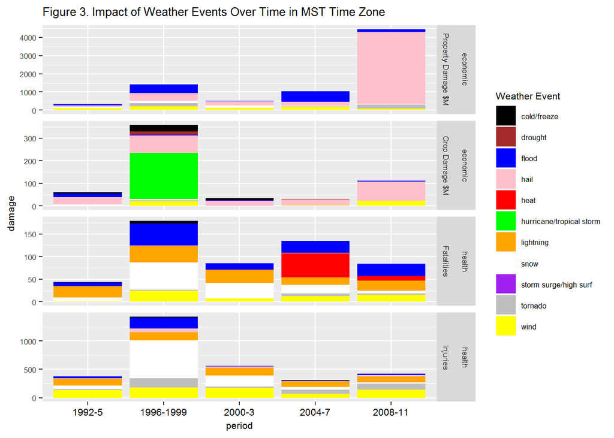

```r
theme_update(text = element_text(size=8))

mycolors= c('black','brown','blue', 'pink','red','green', 'orange',
            'white','purple','gray','yellow')

damage.labs<-c("Property Damage $M","Crop Damage $M","Fatalities","Injuries")
names(damage.labs)<-c("propdamage_M","cropdamage_M","fatalities","injuries")
theme_update(text = element_text(size=8))

mst_plot<-ggplot(subset(casted,time_zone=='MST'),aes(period,y=damage,fill=evtype,order=variable)) +
        geom_bar(stat='identity') + facet_grid(impact+variable ~.,scales="free_y",
                                               labeller=labeller(variable=damage.labs))+
        theme(axis.text.x=element_text(size=8,colour='black',angle=0))+
        ggtitle('Figure 3. Impact of Weather Events Over Time in MST Time Zone')+
        labs(fill="Weather Event", scale_fill_manual(values = mycolors))

# to actually change to my customized colors
mst_plot+ scale_fill_manual(values = mycolors)
```

## Results

The events most harmful to population health and with greatest economic consequences are as follows:

### Heat, flood, tornados were top 3 causes of death and injury, with wind and lightning also consistently big contributors

Fatalities and injuries are the harmful effects to population health. For the time period, event types, and time zones analyzed, there was a total of more than 9,800 fatalities and more than 64,000 injuries. Unlike the concentration in a few event types for economic impact, the health impact was more evenly distributed among event types. In particular, heat, flood, tornados, wind and lightning were consistently the top causes of death, although the deathtoll from tornados grew over time while that from heat declined.

These five weather types were also the main causes of injury; however, tornados were a bigger component of injuries than heat or flooding.

### Flood and hurricanes/tropical storms accounted for most of property damage and second and third causes of crop damage,while drought was number 1 cause of crop damage

Economic consequences are measured by property damage and crop damage. As can be seen from the scales of Figures 1 and 2 and the calculated totals for 1992-2011 for the top 12 event types in the top four time zones, property damage in dollar terms was ~$374 billion, which is nearly 8x the cumulative crop damage of under $46 billion.

Flood and hurricanes/tropical storms accounted most of the property damage, concentrated in the 2004-2007 timeframe and in the EST, CST, and PST timezones. Drought was a major problem in the CST and EST time zones for crop damage. In the MST timezone, much of which is at higher altitudes, hail is the main cause of property and crop damage.